# Gardnerella Core Genome Phylogeny

HLB

October 2020

# Set up

## Packages

```r
library(tidyverse)
```

```r
library(ggrepel)
library(treeio)
library(ggtree)
library(ape)
library(Biostrings)
library(formattable)
library(ggdendro)
library(kableExtra)
library(magick)
`%!in%` <- negate(`%in%`)
```

## File Paths

```r
dataPath <- "/Volumes/GoogleDrive-103667279570938865306/My Drive/Callahan Lab/metagenome_gardnerella/gardPhylogeny"

# Metadata
gardDF <- "./GardnerellaMetadata.csv" %>%
  read_csv() %>%
  filter(in_phylogeny==TRUE)
# phylogeny outputs
prokkaStatsDir <- file.path(dataPath, "prokka_annotated_genomes", "txt")

roaryPresAbs <- "./build_phylogeny/20201002_Roary95/gene_presence_absence.csv" %>%
  read_csv
```

```r
pangenomeStats <- "./build_phylogeny/20201002_Roary95/summary_statistics.txt" %>%
  read_delim(delim="\t", col_names = c("gene_type", "definition", "count")) %>%
  filter(gene_type!="Total genes") %>%
  mutate(gene_type=factor(gene_type, levels=c("Core genes", "Soft core genes", "Shell genes", "Cloud genes")))
gardTree <- "./build_phylogeny/20201005_ml_phylogeny/RAxML_originalLabelledTree.rootedGardTree"
rootedGardTree <- "./build_phylogeny/20201005_ml_phylogeny/RAxML_labelledTree.rootedGardTree"

ffnDir <- file.path(dataPath, "prokka_annotated_genomes", "ffn")

# whole genome mash distances
load(file.path(dataPath, "assembly_quality_control/completeness_quality_dereplication/mashDists.Rdata"))
assemblyDistDF <- mashDists
remove(mashDists)

# output paths
figureOut <- "/Volumes/GoogleDrive-103667279570938865306/My Drive/Callahan Lab/metagenome_gardnerella/FIGURES/V5_manuscript_figures/gard_phyl"
coreGeneFastasDir <- file.path(dataPath, "core_gene_fastas")
assemblyCoreGenesDir <- file.path(dataPath, "assembly_core_genes")
```

## Read in genomes

```r
refAssemblies <- ffnDir %>%
  list.files(pattern = ".ffn", full.names = TRUE) %>%
  map(~readDNAStringSet(.x))

names(refAssemblies) <- ffnDir %>%
  list.files(pattern = ".ffn") %>%
  str_extract(".*(?=\\.ffn)")

# take a look at what sequence names look like
head(names(refAssemblies$`00703Bmash`))
```

```
## [1] "00703Bmash_00001 Nicotinamidase/pyrazinamidase"
## [2] "00703Bmash_00002 hypothetical protein"
## [3] "00703Bmash_00003 hypothetical protein"
## [4] "00703Bmash_00004 hypothetical protein"
## [5] "00703Bmash_00005 hypothetical protein"
## [6] "00703Bmash_00006 Manganese transport system ATP-binding protein MntB"
```

## ggplot

```r
# theme
theme_set(theme_bw()+
          theme(panel.grid = element_blank(),
                axis.text = element_text(size=10),
                axis.title = element_text(size=15),
                legend.text = element_text(size=12),
                legend.title = element_text(size=14)))

# Colors
cladeColors <- list(scale_color_manual(values=c("#CC79A7", "#D55E00", "#56B4E9", "#0072B2", "#E69F00", "#009E73", "#000000"), labels=c("C1", "C2", "C3", "C4", "C5", "C6", bquote('Total'~italic(Gardnerella)))),
                     scale_fill_manual(values=c("#CC79A7", "#D55E00", "#56B4E9", "#0072B2", "#E69F00", "#009E73", "#000000"), labels=c("C1", "C2", "C3", "C4", "C5", "C6", bquote('Total'~italic(Gardnerella)))))

binaryColors <- list(scale_color_manual(values=c("#0072B2", "#D55E00")),
                     scale_fill_manual(values=c("#0072B2", "#D55E00")))

okabeIto <- c("#E69F00", "#F0E442", "#0072B2", "#009E73", "#56B4E9", "#D55E00", "#CC79A7", "#000000")
```

# Gardnerella Assembly Summary Stats

## Genome sizes

```r
meanGenomeLength <- mean(gardDF$total_length)
meanGenomeLength
```

```
## [1] 1612099
```

```r
sd(gardDF$total_length)
```

```
## [1] 93808.3
```

```r
range(gardDF$total_length)
```

```
## [1] 1470925 1944040
```

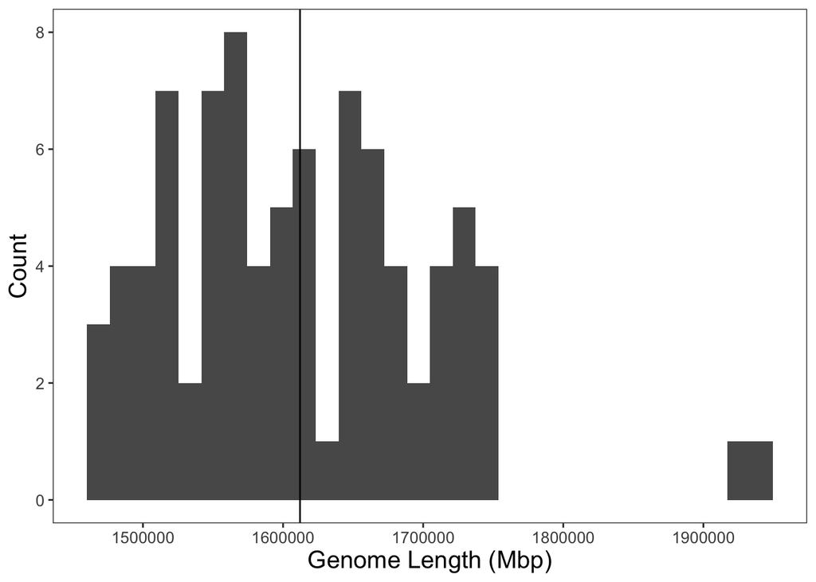

```r
gardDF %>%
  ggplot(aes(total_length)) +
  geom_histogram() +
  geom_vline(xintercept = meanGenomeLength) +
  labs(x="Genome Length (Mbp)", y="Count")
```

```r
#ggsave(file.path(figureOut, "20201009_genomeLengthHist.png"))
```

## Genes identified by Prokka

```r
prokkaStats <- prokkaStatsDir %>%
  list.files(pattern=".txt", full.names = TRUE) %>%
  map(~read_delim(.x, delim="\n", col_names = c("category"))) %>%
  map(~separate(.x, category, into = c("category", "result"), sep=": ")) %>%
  map(~spread(.x, category, result)) %>%
  purrr::reduce(full_join) %>%
  separate(organism, c("Genus", "Species", "Strain"), sep=" ") %>%
  select(Strain, Genus, bases, contigs, gene, mRNA, CDS, rRNA, tRNA, tmRNA, repeat_region)
head(prokkaStats)
```

```
## # A tibble: 6 × 11
##   Strain      Genus bases contigs gene  mRNA  CDS   rRNA  tRNA  tmRNA repeat_region
##   <chr>       <chr> <chr> <chr>   <chr> <chr> <chr> <chr> <chr> <chr> <chr>
## 1 00703Bmash  Gard… 1566… 16      1255  1255  1206  3     45    1     2
## 2 00703C2mash Gard… 1546… 22      1237  1237  1187  4     45    1     2
## 3 00703Dmash  Gard… 1490… 11      1172  1172  1123  3     45    1     <NA>
## 4 0288E       Gard… 1708… 17      1366  1366  1317  3     45    1     <NA>
## 5 101         Gard… 1527… 43      1211  1211  1160  3     47    1     <NA>
## 6 1400E       Gard… 1716… 28      1386  1386  1337  4     44    1     <NA>
```

## Core and Pangenome

Total number of genes in the pangenome:

```r
sum(pangenomeStats$count)
```

```
## [1] 12105
```

Representation:

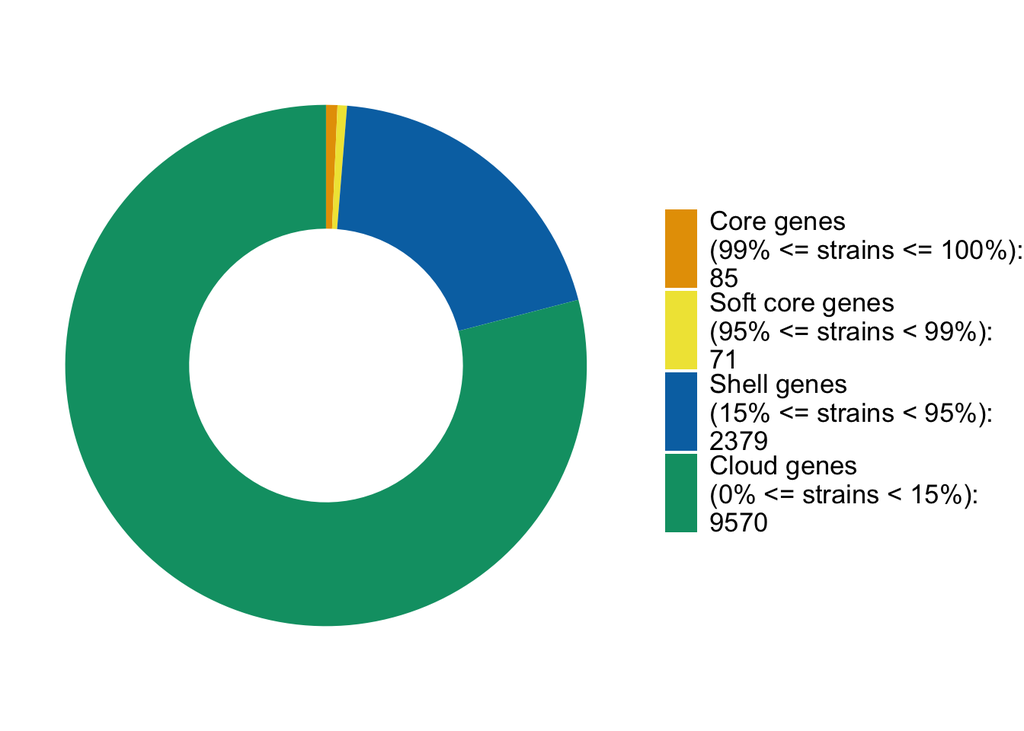

```r
# Donut chart
pangenomeStats %>%
  mutate(fraction=count/sum(count), # compute percentages
         ymax=cumsum(fraction), # cumulative percentages (top of each rectangle)
         ymin=c(0, head(ymax, n=-1)), # bottom of each rectangle
         labelPosition=((ymax+ymin)/2), # label position
         label=paste(gene_type, definition, count, sep="\n")) %>%
  ggplot(aes(ymax=ymax, ymin=ymin, xmax=20, xmin=1, fill=gene_type)) +
  geom_rect() +
  #geom_text_repel(x=21, aes(y=labelPosition, label=label), size=5) + # x here controls label position (inner / outer)
  scale_fill_manual(values=okabeIto[1:4], labels=paste0(pangenomeStats$gene_type, "\n", pangenomeStats$definition, ":\n", pangenomeStats$count)) +
  coord_polar(theta="y") +
  xlim(c(-20, 20)) +
  theme_void() +
  theme(legend.position = "right",
        legend.text = element_text(size=13)) +
  labs(fill=NULL)
```

```r
#ggsave(file.path(figureOut, "20210819_corePanGenesFraction.png"))
```

# Gardnerella Phylogeny

```r
tree <- "./build_phylogeny/20201005_ml_phylogeny/RAxML_bipartitionsBranchLabels.bootstrappedGardTree" %>%
  read.raxml()

root <- "./build_phylogeny/20201005_ml_phylogeny/RAxML_labelledTree.rootedGardTree" %>%
  treeio::read.newick()

placement <- "./build_phylogeny/20201005_ml_phylogeny/RAxML_portableTree.rootedGardTree.jplace" %>%
  read.jplace()
```

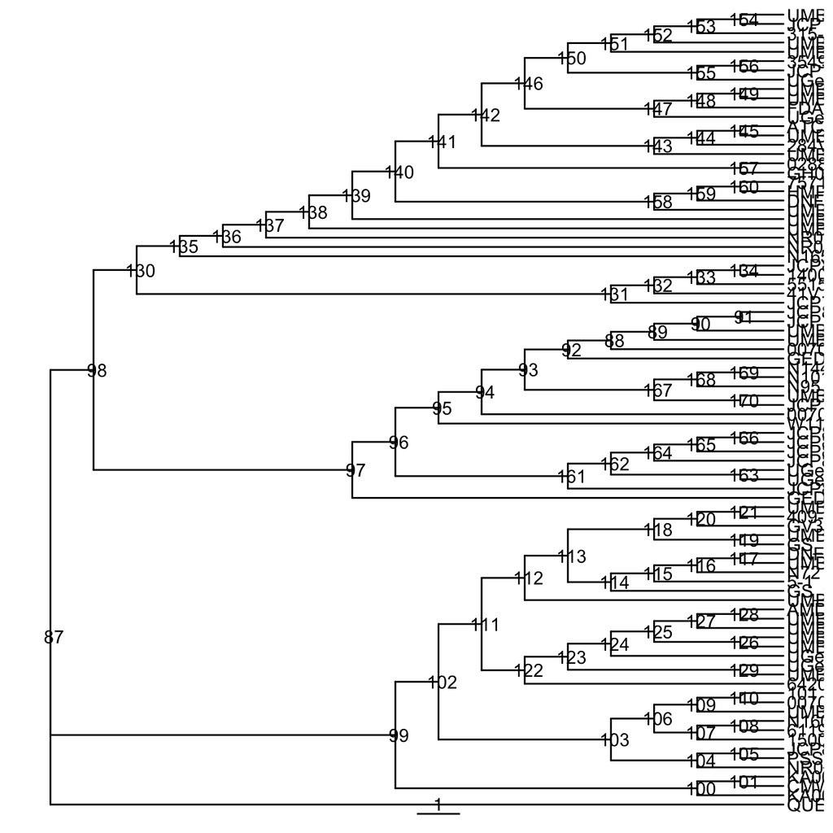

```r
outgroupRootTree <- root %>%
  root(outgroup="QUERY___B_longum_51A")

outgroupRootTree %>%
  ggtree(branch.length = "none") +
  geom_tiplab() +
  geom_nodelab(mapping=aes(label=node)) +
  geom_treescale()
```

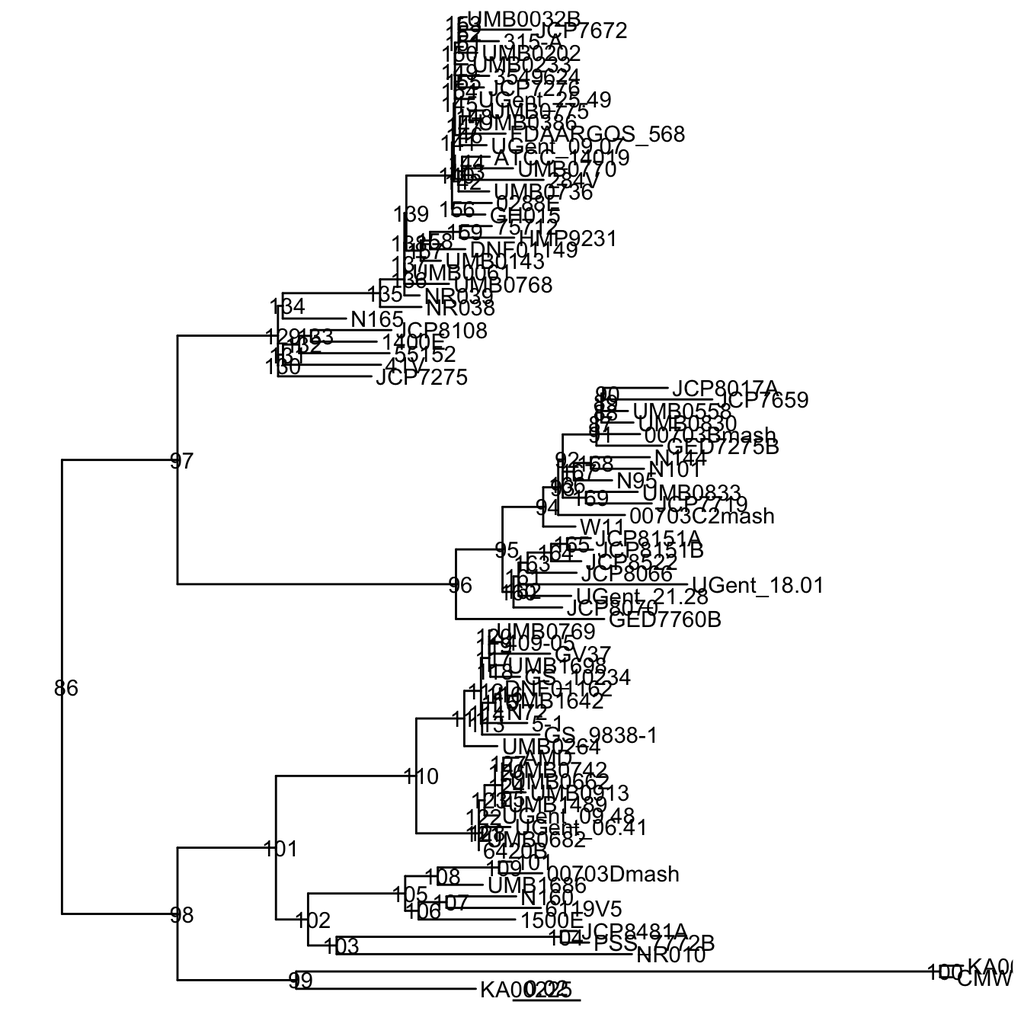

```r
outgroupRootTree %>%
  drop.tip("QUERY___B_longum_51A") %>%
  ggtree() +
  geom_tiplab() +
  geom_nodelab(mapping=aes(label=node)) +
  geom_treescale()
```

# Define Clade and Genomospecies Dataframe

## Clades

```r
C1 <- outgroupRootTree %>%
  tree_subset("JCP7275", levels_back=2) %>%
  .$tip.label
C1
```

```
##  [1] "41V"          "55152"        "1400E"        "JCP8108"      "JCP7275"
##  [6] "N165"         "UMB0768"      "UMB0061"      "UMB0736"      "UMB0770"
## [11] "ATCC_14019"   "284V"         "UMB0386"      "UMB0775"      "FDAARGOS_568"
## [16] "UGent_09.07"  "UMB0233"      "JCP7672"      "UMB0032B"     "315-A"
## [21] "UMB0202"      "UGent_25.49"  "JCP7276"      "3549624"      "GH015"
## [26] "0288E"        "UMB0143"      "HMP9231"      "75712"        "DNF01149"
## [31] "NR039"        "NR038"
```

```r
C2 <- outgroupRootTree %>%
   tree_subset("W11", levels_back=2) %>%
  .$tip.label
C2
```

```
##  [1] "00703Bmash"  "UMB0830"     "JCP7659"     "JCP8017A"    "UMB0558"
##  [6] "GED7275B"    "00703C2mash" "W11"         "GED7760B"    "JCP8070"
## [11] "UGent_21.28" "UGent_18.01" "JCP8066"     "JCP8151B"    "JCP8151A"
## [16] "JCP8522"     "N95"         "N101"        "N144"        "JCP7719"
## [21] "UMB0833"
```

```r
C3 <- outgroupRootTree %>%
  tree_subset("NR010", levels_back=2) %>%
  .$tip.label
C3
```

```
## [1] "PSS_7772B"  "JCP8481A"   "NR010"      "6119V5"     "N160"
## [6] "1500E"      "UMB1686"    "00703Dmash" "101"
```

```r
C4 <- outgroupRootTree %>%
  tree_subset("6420B", levels_back=2) %>%
  .$tip.label
C4
```

```
##  [1] "UMB0264"     "GS_9838-1"   "5-1"         "N72"         "UMB1642"
##  [6] "DNF01162"    "GS_10234"    "UMB1698"     "GV37"        "409-05"
## [11] "UMB0769"     "6420B"       "UMB1489"     "UMB0913"     "UMB0662"
## [16] "UMB0742"     "AMD"         "UGent_09.48" "UMB0682"     "UGent_06.41"
```

```r
C5 <- c("KA00735", "CMW7778B")

C6 <- "KA00225"
```

## Genomospecies

### Unclear genomospecies NR010? W11? N160?

**W11**  
W11 genomospecies identity is unclear by placement on phylogeny. It was labeled genomospecies 3 by Khan et al., 2020 “A generalist lifestyle allows rare Gardnerella spp. to persist at low levels in the vaginal microbiome” *Microbial Ecology*.

```r
# closest whole genome mash distance function
smallestANI <- function(STRAIN){
  DF <- assemblyDistDF %>%
    filter(assembly1==gardDF$GenBank_accession[gardDF$Strain==STRAIN]|assembly2==gardDF$GenBank_accession[gardDF$Strain==STRAIN]) %>%
    filter(distance==min(distance)) %>%
    mutate(strain1=gardDF$Strain[gardDF$GenBank_accession==assembly1],
           strain2=gardDF$Strain[gardDF$GenBank_accession==assembly2],
           ANI=1-distance) %>%
    select(strain1, strain2, distance, ANI)
  return(DF)
}

smallestANI("W11")
```

```
##       strain1 strain2  distance       ANI
## 1 00703C2mash     W11 0.0226378 0.9773622
```

Closest by approximate whole genome ANI is 00703C2mash (GS3) at about 98%.

**NR010**

```r
smallestANI("NR010")
```

```
##   strain1 strain2 distance      ANI
## 1 UMB1686   NR010 0.102268 0.897732
```

Smallest approximate ANI is ~90%. Genomospecies 14. **N160** N160 appears to be in GS9 based on this phylogeny, by Khan et al. appears to place it in GS10. Unsure their method, but possibly by *cpn60* sequence.

```r
smallestANI("N160")
```

```
##   strain1 strain2  distance       ANI
## 1  6119V5    N160 0.0230043 0.9769957
```

Closest by whole genome mash distance is strain 6119V5 (GS9) with ~98% ANI.

Check *cpn60* sequence

```r
cpn60s <- refAssemblies %>%
  map(~.x[str_detect(names(.x), "60 kDa chaperonin")])

names(cpn60s) <- NULL #remove list names to flatten string set

cpn60s <- cpn60s %>% # flatten string set
  do.call(c,.)

names(cpn60s) <- str_extract(names(cpn60s), ".*(?=_[0-9]{5}.*)") # remove annotation from DNA String set names to get just strain names

cpn60s# print
```

```
## DNAStringSet object of length 85:
##      width seq                                              names
##  [1]  1626 ATGGCAAAGATTATTGCCTATGA...CGGCGCAGAGATGGGCTACTAA 00703Bmash
##  [2]  1626 ATGGCAAAGATTATTGCCTATGA...CGGCGCAGAGATGGGCTACTAA 00703C2mash
##  [3]  1626 ATGGCAAAGATTATTGCCTATGA...TGGCGCTGATATGGGTTACTAA 00703Dmash
##  [4]  1626 ATGGCAAAGATTATTGCCTATGA...TGGCGCAGAGATGGGCTACTAA 0288E
##  [5]  1626 ATGGCAAAGATTATTGCCTATGA...TGGCGCTGATATGGGTTACTAA 101
##  ...   ... ...
## [81]  1626 ATGGCAAAGATTATTGCCTATGA...TGGTGCCGACATGGGCTACTAA UMB1489
## [82]  1626 ATGGCAAAGATTATTGCCTACCA...TGGTGCCGACATGGGCTACTAA UMB1642
## [83]  1626 ATGGCAAAGATTATTGCCTATGA...TGGCGCTGATATGGGTTACTAA UMB1686
## [84]  1626 ATGGCAAAGATTATTGCCTACCA...TGGTGCCGACATGGGCTACTAA UMB1698
## [85]  1626 ATGGCAAAGATTATTGCCTATGA...CGGCGCAGAGATGGGCTACTAA W11
```

Calculate distances

```r
cpn60Dists <- cpn60s %>%
  rMSA::distAlignment(cpn60s) %>%
  as.matrix() %>%
  data.frame(check.names = FALSE) %>%
  rownames_to_column("strain1") %>%
  gather("strain2", "dist", 2:ncol(.)) %>% #flatten matrix
  filter(strain1!=strain2) #remove diagonal
```

Get minimum distance:

```r
cpn60Dists %>%
  filter(strain1=="N160") %>%
  filter(dist==min(dist))
```

```
##   strain1 strain2 dist
## 1    N160   1500E    9
```

Using full-length *cpn60* sequence N160 would be placed into GS10, as its *cpn60* sequence is closest to 1500E. Compare distances to 1500E (GS10) and 6119V5 (GS9)

```r
cpn60Dists %>%
  filter(strain1=="N160",
         strain2 %in% c("6119V5", "1500E"))
```

```
##   strain1 strain2 dist
## 1    N160   1500E    9
## 2    N160  6119V5   12
```

The sequences are close, and they are also close phylogenetically.

Check placement based on the UT region, which would be used in PCR:

```r
cpn60UTDists <- cpn60s %>%
  substr(241, 847) %>% #substring to UT region
  rMSA::distAlignment(cpn60s) %>%
  as.matrix() %>%
  data.frame(check.names = FALSE) %>%
  rownames_to_column("strain1") %>%
  gather("strain2", "dist", 2:ncol(.)) %>% #flatten matrix
  filter(strain1!=strain2) #remove diagonal
```

Get minimum distance:

```r
cpn60Dists %>%
  filter(strain1=="N160") %>%
  filter(dist==min(dist))
```

```
##   strain1 strain2 dist
## 1    N160   1500E    9
```

Same result of placement in GS10.

Compare distances to 1500E (GS10) and 6119V5 (GS9)

```r
cpn60Dists %>%
  filter(strain1=="N160",
         strain2 %in% c("6119V5", "1500E"))
```

```
##   strain1 strain2 dist
## 1    N160   1500E    9
## 2    N160  6119V5   12
```

Again, same result as full-length.

### Define genomospecies identities

```r
GS1 <- outgroupRootTree %>%
  tree_subset("N165", levels_back=1) %>%
  .$tip.label
GS2 <-c("JCP7275", "41V", "55152", "1400E", "JCP8108")
GS3 <- outgroupRootTree %>%
  tree_subset("00703C2mash", levels_back=4) %>%
  .$tip.label
GS4 <- outgroupRootTree %>%
  tree_subset("JCP8070", levels_back=1) %>%
  .$tip.label
GS5 <- outgroupRootTree %>%
  tree_subset("6420B", levels_back=1) %>%
  .$tip.label
GS6 <- outgroupRootTree %>%
  tree_subset("UMB0264", levels_back=1) %>%
  .$tip.label
GS7 <- c("JCP8481A", "PSS_7772B")
GS8 <- c("101", "00703Dmash", "UMB1686")
GS9 <- c("6119V5", "N160")
GS10 <- "1500E"
GS11 <- "GED7760B"
GS12 <- c("KA00735", "CMW7778B")
GS13 <- "KA00225"
GS14 <- "NR010"
```

## Clade and genomoospecies dataframe

```r
cladeGSDF <- gardDF %>%
  select(Strain) %>%
  mutate(Genomospecies=case_when(Strain %in% GS1 ~ "GS1",
                                 Strain %in% GS2 ~ "GS2",
                                 Strain %in% GS3 ~ "GS3",
                                 Strain %in% GS4 ~ "GS4",
                                 Strain %in% GS5 ~ "GS5",
                                 Strain %in% GS6 ~ "GS6",
                                 Strain %in% GS7 ~ "GS7",
                                 Strain %in% GS8 ~ "GS8",
                                 Strain %in% GS9 ~ "GS9",
                                 Strain %in% GS10 ~ "GS10",
                                 Strain %in% GS11 ~ "GS11",
                                 Strain %in% GS12 ~ "GS12",
                                 Strain %in% GS13 ~ "GS13",
                                 Strain %in% GS14 ~ "GS14"),
         Clade=case_when(Strain %in% C1 ~ "C1",
                         Strain %in% C2 ~ "C2",
                         Strain %in% C3 ~ "C3",
                         Strain %in% C4 ~ "C4",
                         Strain %in% C5 ~ "C5",
                         Strain %in% C6 ~ "C6"))

# save clade and genomospecies dataframe
# write_csv(cladeGSDF, "../refGardnerellaCladesGenomos.csv")
```

# Single-Copy Core Genes

```r
coreGenes <- roaryPresAbs %>%
  filter(`No. isolates`==85)

# check single copy
coreGenes$`Avg sequences per isolate` %>%
  table
```

```
## .
##  1
## 85
```

## Testing core genome annotation counts in pangenome

Use strict definition of annotation of gene family appearing only once, to ensure only single-copy core genes are used in the All replicated annotations:

```r
replicatedGeneFamilies <- roaryPresAbs %>%
  group_by(Annotation) %>%
  summarise(n=n()) %>%
  filter(n>1) %>%
  .$Annotation

length(replicatedGeneFamilies)
```

```
## [1] 607
```

Observe core genes with replicated annotations and get single-copy core genes

```r
replicatedCoreGeneFamilies <- coreGenes$Annotation[coreGenes$Annotation %in% replicatedGeneFamilies]
replicatedCoreGeneFamilies
```

```
##  [1] "hypothetical protein"
##  [2] "2,3-bisphosphoglycerate-dependent phosphoglycerate mutase"
##  [3] "Glutamine synthetase"
##  [4] "putative RNA pseudouridine synthase"
##  [5] "hypothetical protein"
##  [6] "Ribose-phosphate pyrophosphokinase"
##  [7] "hypothetical protein"
##  [8] "Chaperone protein DnaK"
##  [9] "hypothetical protein"
## [10] "Glutamine synthetase"
## [11] "hypothetical protein"
## [12] "Aspartokinase"
## [13] "Ribulose-phosphate 3-epimerase"
## [14] "1,4-alpha-glucan branching enzyme GlgB"
## [15] "DNA gyrase subunit B"
```

```r
length(replicatedCoreGeneFamilies)
```

```
## [1] 15
```

```r
singleCopyCoreGenes <- coreGenes %>%
  filter(Annotation %!in% replicatedGeneFamilies)

nrow(singleCopyCoreGenes)
```

```
## [1] 70
```

```r
#sanity check
(nrow(singleCopyCoreGenes)+length(replicatedCoreGeneFamilies)) == length(coreGenes$Annotation)
```

```
## [1] TRUE
```

# Dereplicate sequences within clades/genomospeices

```r
strains <- gardDF$Strain

# Gene ID lists by Strain
coreGenesByStrain <- singleCopyCoreGenes %>%
  select(all_of(strains)) %>%
  as.list() %>%
  map(~paste(.x, collapse = "|")) %>%
  .[names(refAssemblies)] # reorder to match order of ffn files

head(coreGenesByStrain)[1:2]
```

```
## $`00703Bmash`
## [1] "00703Bmash_00392|00703Bmash_00494|00703Bmash_00895|00703Bmash_00976|00703Bmash_00951|00703Bmash_00781|00703Bmash_00232|00703Bmash_00350|00703Bmash_00677|00703Bmash_00792|00703Bmash_00998|00703Bmash_00279|00703Bmash_00320|00703Bmash_00360|00703Bmash_00376|00703Bmash_00393|00703Bmash_00521|007…
##
## $`00703C2mash`
## [1] "00703C2mash_00964|00703C2mash_00869|00703C2mash_01154|00703C2mash_01073|00703C2mash_01098|00703C2mash_00209|00703C2mash_00502|00703C2mash_00690|00703C2mash_00156|00703C2mash_00058|00703C2mash_01051|00703C2mash_00652|00703C2mash_00732|00703C2mash_00680|00703C2mash_00980|00703C2mash_00963|0070…
```

```r
# Gene ID lists by gene family
coreGenesByFamily <- singleCopyCoreGenes %>%
  select(Gene, all_of(strains)) %>%
  column_to_rownames(var = "Gene") %>%
  t() %>%
  as.data.frame() %>%
  as.list()

head(coreGenesByFamily)[1:2]
```

```
## $rpsT
##  [1] "409-05_00825"       "ATCC_14019_00886"   "101_00704"
##  [4] "41V_01213"          "AMD_00331"          "5-1_00951"
##  [7] "HMP9231_00659"      "315-A_00452"        "284V_00877"
## [10] "55152_00329"        "1400E_01329"        "00703C2mash_00964"
## [13] "75712_00740"        "0288E_00943"        "6420B_00089"
## [16] "1500E_00369"        "00703Bmash_00392"   "00703Dmash_00934"
## [19] "6119V5_01026"       "JCP8522_00129"      "JCP8481A_00850"
## [22] "JCP8151B_00956"     "JCP8151A_01078"     "JCP8108_00448"
## [25] "JCP8070_00670"      "JCP8066_00482"      "JCP8017A_00601"
## [28] "JCP7719_00703"      "JCP7672_00707"      "JCP7659_00753"
## [31] "JCP7276_00294"      "JCP7275_00574"      "3549624_00096"
## [34] "GED7275B_01177"     "GED7760B_00473"     "PSS_7772B_00406"
## [37] "CMW7778B_00306"     "GV37_00977"         "UMB0913_00800"
## [40] "UMB0061_01052"      "UMB0833_00022"      "UMB0830_00815"
```

[output cut: 46 more lines]

```r
length(coreGenesByFamily)
```

```
## [1] 70
```

## select only core genomes

```r
coreGeneSeqs <- refAssemblies %>%
  map2(coreGenesByStrain, ~.x[str_detect(names(.x), .y)])

# length test
lengthTest <- map(coreGeneSeqs, length) %>%
  unlist
names(lengthTest) <- NULL
table(lengthTest)
```

```
## lengthTest
## 70
## 85
```

70 single-copy core genes for all 85 genome assemblies.

### Save fasta files of core genomes of each assembly

```r
#map2(coreGeneSeqs, names(refAssemblies), ~writeXStringSet(.x, filepath = file.path(assemblyCoreGenesDir, paste0(.y, ".fasta")), format="fasta"))
```

# Select representatives

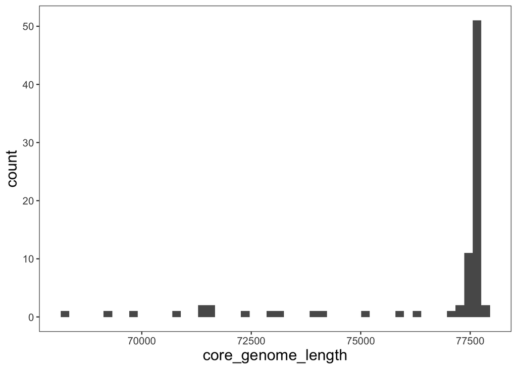

```r
names(coreGeneSeqs) <- names(refAssemblies)

coreSelectDF <- coreGeneSeqs %>%
  .[names(coreGeneSeqs) %!in% c("N165", "JCP7275")] %>% # remove assemblies we are not using for mapping
  as.list() %>%
  map_df(., width) %>% #core genome lengths
  colSums() %>%
  as.data.frame() %>%
  dplyr::rename(core_genome_length=".") %>%
  rownames_to_column(var="Strain") %>%
  left_join(cladeGSDF, by="Strain") %>%
  left_join(gardDF[,c("Strain", "assembly_level", "contig_N50", "contig_L50")], by="Strain") %>%
  replace_na(list(contig_N50=9999999, contig_L50=1)) # replace values in complete assemblies

coreSelectDF %>%
  ggplot(aes(core_genome_length)) +
  geom_histogram(bins = 50)
```

```r
coreSelectDF %>%
  group_by(assembly_level) %>%
  summarise(mean=mean(core_genome_length),
            min=min(core_genome_length),
            firstQ=quantile(core_genome_length, c(0.25)),
            median=median(core_genome_length),
            thirdQ=quantile(core_genome_length, c(0.75)),
            max=max(core_genome_length))
```

```
## # A tibble: 4 × 7
##   assembly_level    mean   min firstQ median thirdQ   max
##   <chr>            <dbl> <dbl>  <dbl>  <dbl>  <dbl> <dbl>
## 1 Chromosome      77595  77595  77595  77595 77595  77595
## 2 Complete Genome 77522. 77235  77574  77574 77574  77652
## 3 Contig          77583. 77079  77562  77577 77631  77829
## 4 Scaffold        75684. 68220  73797  77535 77608. 77709
```

```r
# all sizes
coreSelectDF %>%
  .$core_genome_length %>%
  summary
```

```
##    Min. 1st Qu.  Median    Mean 3rd Qu.    Max.
##   68220   77500   77574   76572   77619   77829
```

Use median complete assembly genome core genome length of 77574 as reference length. Is also the median of all core genome lengths

Select one core genome per genomospecies

```r
includeCoreGenomes <- coreSelectDF %>%
  group_by(Genomospecies) %>%
  filter(contig_N50==max(contig_N50)) %>% # first criterion is assembly quality
  filter(abs(core_genome_length-77574)==min(abs(core_genome_length-77574))) %>% # second criterion is core genome length
  filter(Strain!="GV37") %>% # still a duplicate in GS 6, keep 409-05
  .$Strain
```

Make sure each clade is represented and each genomospecies is represented

```r
cladeGSDF %>%
  filter(Strain %in% includeCoreGenomes) %>%
  group_by(Clade) %>%
  tally()
```

```
## # A tibble: 6 × 2
##   Clade     n
##   <chr> <int>
## 1 C1        2
## 2 C2        3
## 3 C3        5
## 4 C4        2
## 5 C5        1
## 6 C6        1
```

```r
cladeGSDF %>%
  filter(Strain %in% includeCoreGenomes) %>%
  group_by(Genomospecies) %>%
  tally()
```

```
## # A tibble: 14 × 2
##    Genomospecies     n
##    <chr>         <int>
##  1 GS1               1
##  2 GS10              1
##  3 GS11              1
##  4 GS12              1
##  5 GS13              1
##  6 GS14              1
##  7 GS2               1
##  8 GS3               1
##  9 GS4               1
## 10 GS5               1
## 11 GS6               1
## 12 GS7               1
## 13 GS8               1
## 14 GS9               1
```

Save mapping core genome database

```r
# Sequences
coreRefDB <- coreGeneSeqs[names(coreGeneSeqs) %in% includeCoreGenomes] %>%
  `names<-`(NULL) %>%
   do.call(c, .)
# remove annotations from name
names(coreRefDB) <- str_extract(names(coreRefDB), ".*_[0-9]{5}")

singleCopyCoreGenes0 <- singleCopyCoreGenes %>%
  select(Gene, Annotation, strains) %>%
  gather("Strain", "reference", strains) %>%
  dplyr::rename(gene=Gene,
                annotation=Annotation)
```

```
## Note: Using an external vector in selections is ambiguous.
## ℹ Use `all_of(strains)` instead of `strains` to silence this message.
## ℹ See <https://tidyselect.r-lib.org/reference/faq-external-vector.html>.
```

```r
# Create reference data frame
coreRefDB_DF <- coreRefDB %>%
  names() %>%
  as.data.frame() %>%
  dplyr::rename(reference=".") %>%
  left_join(singleCopyCoreGenes0, by="reference") %>%
  left_join(cladeGSDF, by="Strain")

# save files
#writeXStringSet(coreRefDB, filepath = "../clade_assignments/ref_genes/refGenes.fasta") # fasta of sequences
#write_csv(coreRefDB_DF, "../clade_assignments/ref_genes/refGenesDF.csv") #data frame
```

# Table of Reference Gardnerella Genomes

```r
gardTable <- gardDF %>%
  select(Strain, Genus, GenBank_accession) %>%
  left_join(cladeGSDF, by="Strain") %>%
  mutate(Species=case_when(Genomospecies=="GS1"~"vaginalis",
                           Genomospecies=="GS4"~"piotii",
                           Genomospecies=="GS5"~"leopoldii",
                           Genomospecies=="GS6"~"swidsinskii",
                           Genomospecies %!in% c("GS1", "GS4", "GS5", "GS6")~paste0("sp. ", str_extract(Genomospecies, "(?<=GS)[0-9]+"))),
         `In Mapping DB`=(Strain %in% includeCoreGenomes),
         Genomospecies=factor(Genomospecies, levels=c("GS1", "GS2", "GS3", "GS4", "GS5", "GS6", "GS7", "GS8", "GS9", "GS10", "GS11", "GS12", "GS13", "GS14"))) %>%
  dplyr::rename(Accession=GenBank_accession) %>%
  select(Strain, Genus, Species, Genomospecies, Clade, `In Mapping DB`, Accession) %>%
  arrange(Genomospecies) %>%
  kbl(caption = "Table 1. Reference Gardnerella Genomes") %>%
  kable_classic(full_width=TRUE, html_font = "Arial") %>%
  row_spec(0, bold = TRUE)
gardTable
```

Table 1. Reference Gardnerella Genomes

| Strain | Genus | Species | Genomospecies | Clade | In Mapping DB | Accession |
| --- | --- | --- | --- | --- | --- | --- |
| ATCC_14019 | Gardnerella | vaginalis | GS1 | C1 | TRUE | GCA_000159155.2 |
| HMP9231 | Gardnerella | vaginalis | GS1 | C1 | FALSE | GCA_000213955.1 |
| 315-A | Gardnerella | vaginalis | GS1 | C1 | FALSE | GCA_000214315.2 |
| 284V | Gardnerella | vaginalis | GS1 | C1 | FALSE | GCA_000263435.1 |
| 75712 | Gardnerella | vaginalis | GS1 | C1 | FALSE | GCA_000263535.1 |
| 0288E | Gardnerella | vaginalis | GS1 | C1 | FALSE | GCA_000263555.1 |
| JCP7672 | Gardnerella | vaginalis | GS1 | C1 | FALSE | GCA_000414645.1 |
| JCP7276 | Gardnerella | vaginalis | GS1 | C1 | FALSE | GCA_000414685.1 |
| 3549624 | Gardnerella | vaginalis | GS1 | C1 | FALSE | GCA_001049785.1 |
| UMB0061 | Gardnerella | vaginalis | GS1 | C1 | FALSE | GCA_002861165.1 |
| UMB0775 | Gardnerella | vaginalis | GS1 | C1 | FALSE | GCA_002861925.1 |
| UMB0770 | Gardnerella | vaginalis | GS1 | C1 | FALSE | GCA_002861945.1 |
| UMB0386 | Gardnerella | vaginalis | GS1 | C1 | FALSE | GCA_002861965.1 |
| UMB0032B | Gardnerella | vaginalis | GS1 | C1 | FALSE | GCA_002862005.1 |
| UMB0233 | Gardnerella | vaginalis | GS1 | C1 | FALSE | GCA_002862045.1 |
| UMB0768 | Gardnerella | vaginalis | GS1 | C1 | FALSE | GCA_002884835.1 |
| DNF01149 | Gardnerella | vaginalis | GS1 | C1 | FALSE | GCA_002894105.1 |
| UGent_25.49 | Gardnerella | vaginalis | GS1 | C1 | FALSE | GCA_003397605.1 |
| UGent_09.07 | Gardnerella | vaginalis | GS1 | C1 | FALSE | GCA_003397665.1 |
| GH015 | Gardnerella | vaginalis | GS1 | C1 | FALSE | GCA_003408745.1 |
| N165 | Gardnerella | vaginalis | GS1 | C1 | FALSE | GCA_003408785.1 |
| NR038 | Gardnerella | vaginalis | GS1 | C1 | FALSE | GCA_003585655.1 |
| NR039 | Gardnerella | vaginalis | GS1 | C1 | FALSE | GCA_003585755.1 |
| FDAARGOS_568 | Gardnerella | vaginalis | GS1 | C1 | FALSE | GCA_003812765.1 |
| UMB0143 | Gardnerella | vaginalis | GS1 | C1 | FALSE | GCA_013315005.1 |
| UMB0736 | Gardnerella | vaginalis | GS1 | C1 | FALSE | GCA_013315025.1 |
| UMB0202 | Gardnerella | vaginalis | GS1 | C1 | FALSE | GCA_013315075.1 |
| 41V | Gardnerella | sp. 2 | GS2 | C1 | FALSE | GCA_000165635.2 |
| 55152 | Gardnerella | sp. 2 | GS2 | C1 | FALSE | GCA_000263475.1 |
| 1400E | Gardnerella | sp. 2 | GS2 | C1 | TRUE | GCA_000263495.1 |

[output cut: 55 more lines]

```r
#save_kable(gardTable, file = file.path(figureOut, paste(Sys.Date(), "GardRefTable.png", sep="_")), zoom = 4)
```